# Hankowsky_HW3

Keith Hankowsky

2022-09-22

**General Comments [Gallagher’s comments in magenta]: Superb work on all 4 problems. I think your analysis of 4.31 with the rank sum test should have been based on the Welch test, but the Sleuth authors make the same mistake. As in Case Study 4.1, they fail to appreciate the problems of unequal spread on the rank sum test and t.tests. Basic score (5+5/10, Supplemental Score (2.5+2.5)/5 Total score 15/10**

Hankowsky Homework Solutions

# Basic Problems

## 4.28

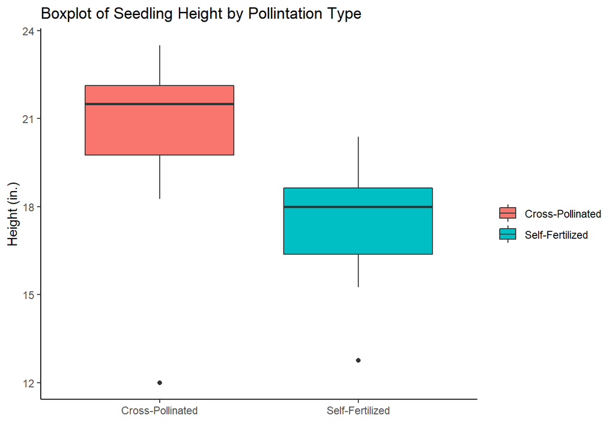

```r
#pulling the data from the 'Sleuth 3' package
seedling <- Sleuth3::ex0428

#transposing the data so it is in long format
seedling_long <- seedling %>%
  pivot_longer(cols = c(Cross, Self),
               names_to = "Pollination",
               values_to = "Height") %>%
  mutate(Pollination = as.factor(Pollination))

#creating a new variable
seedling <- seedling %>%
  mutate(diff = Cross - Self)


###############################################################################


#boxplot of seedling height by pollination type
seedling_long %>%
  ggplot() +
  geom_boxplot(aes(x = Pollination, y = Height, fill = Pollination)) +
  scale_x_discrete(labels = c("Cross-Pollinated", "Self-Fertilized")) +
  scale_fill_discrete(name = "", labels = c("Cross-Pollinated", "Self-Fertilized")) +
  labs(title = "Boxplot of Seedling Height by Pollintation Type",
       x = "", y = "Height (in.)") +
  theme_classic()
```

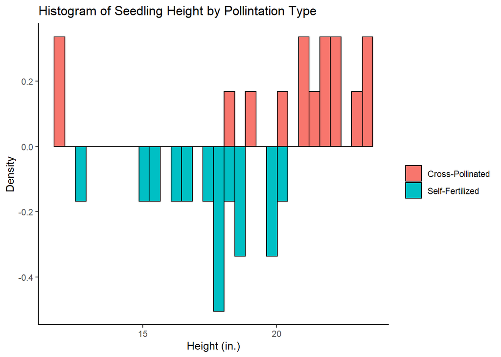

```r
#histogram of seedling height by pollination type
seedling_long %>%
  ggplot() +
  geom_histogram(data = seedling_long %>%
                   filter(Pollination == "Cross"),
                 aes(x = Height, y = ..density.., fill = Pollination), color = "black") +
  geom_histogram(data = seedling_long %>%
                   filter(Pollination == "Self"),
                 aes(x = Height, y = -..density.., fill = Pollination), color = "black") +
  scale_fill_discrete(name = "", labels = c("Cross-Pollinated", "Self-Fertilized")) +
  labs(title = "Histogram of Seedling Height by Pollintation Type",
       y = "Density", x = "Height (in.)") +
  theme_classic()
```

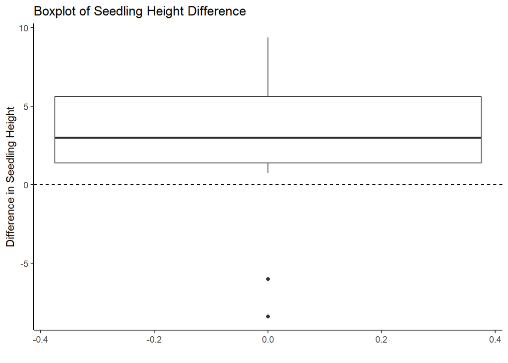

```r
###############################################################################


#boxplot of the difference in seedling height
seedling %>%
  ggplot() +
  geom_boxplot(aes(y = diff)) +
  labs(title = "Boxplot of Seedling Height Difference",
       y = "Difference in Seedling Height",
       x = "") +
  geom_hline(yintercept = 0, linetype = 2) +
  theme_classic()
```

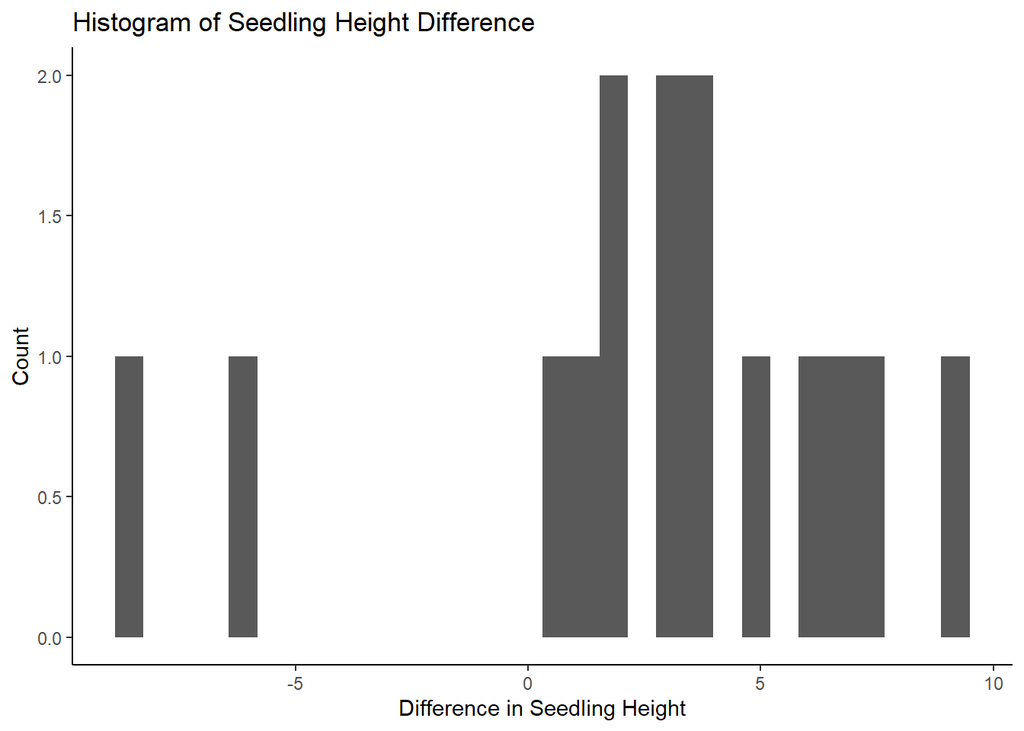

```r
#histogram of the difference in seedling height
seedling %>%
  ggplot() +
  geom_histogram(aes(x = diff)) +
  labs(title = "Histogram of Seedling Height Difference",
       x = "Difference in Seedling Height",
       y = "Count") +
  theme_classic()
```

```r
###############################################################################


#running the paired t-test
t.test(Height ~ Pollination, data = seedling_long, paired = TRUE)
```

```
##
##  Paired t-test
##
## data:  Height by Pollination
## t = 2.1474, df = 14, p-value = 0.04976
## alternative hypothesis: true mean difference is not equal to 0
## 95 percent confidence interval:
##  0.003165044 5.230168289
## sample estimates:
## mean difference
##        2.616667
```

```r
#running the Wilcoxon Signed-Rank Test
wilcox.test(Height ~ Pollination, data = seedling_long, paired = TRUE)
```

```
##
##  Wilcoxon signed rank exact test
##
## data:  Height by Pollination
## V = 96, p-value = 0.04126
## alternative hypothesis: true location shift is not equal to 0
```

```r
#running the Wilcoxon Signed-Rank Test from the {asht} package
wsrTest(seedling$Cross, seedling$Self)
```

```
##
##  Exact Wilcoxon Signed-Rank Test (with Pratt modification if zeros)
##
## data:  seedling$Cross minus seedling$Self
## p-value = 0.04126
## alternative hypothesis: true median is not equal to 0
## 95 percent confidence interval:
##  0.499 5.190
## sample estimates:
## median (Hodges-Lehmann estimator)
##                           3.13625
```

**Basic Sleuth3::4.28:**Your answer was excellent! I don’t have a single criticism. The wsrTest program finds the Hodges-Lehman estimator and uses an iterative procedure to find the 95% CIs.s**Score: 5/5**

## 4.32

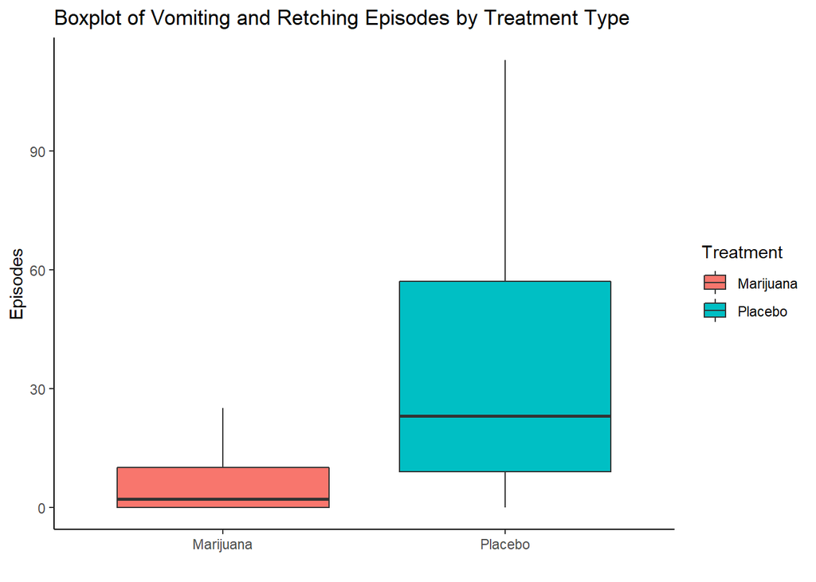

```r
#pulling the data from the 'Sleuth 3' package
cancer <- Sleuth3::ex0432

#transposing the data so it is in long format
cancer_long <- cancer %>%
  pivot_longer(cols = c(Marijuana, Placebo),
               names_to = "Treatment",
               values_to = "Episodes") %>%
  mutate(Treatment = as.factor(Treatment),
         log_episodes = log(Episodes + 1))


#boxplot of vomiting and retching episodes by treatment type
cancer_long %>%
  ggplot() +
  geom_boxplot(aes(x = Treatment, y = Episodes, fill = Treatment)) +
  labs(title = "Boxplot of Vomiting and Retching Episodes by Treatment Type",
       x = "") +
  theme_classic()
```

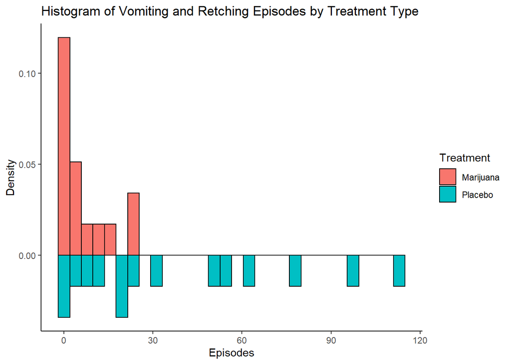

```r
#histogram of vomiting and retching episodes by treatment type
cancer_long %>%
  ggplot() +
  geom_histogram(data = cancer_long %>%
                   filter(Treatment == "Marijuana"),
                 aes(x = Episodes, y = ..density.., fill = Treatment), color = "black") +
  geom_histogram(data = cancer_long %>%
                   filter(Treatment == "Placebo"),
                 aes(x = Episodes, y = -..density.., fill = Treatment), color = "black") +
  labs(title = "Histogram of Vomiting and Retching Episodes by Treatment Type",
       y = "Density") +
  theme_classic()
```

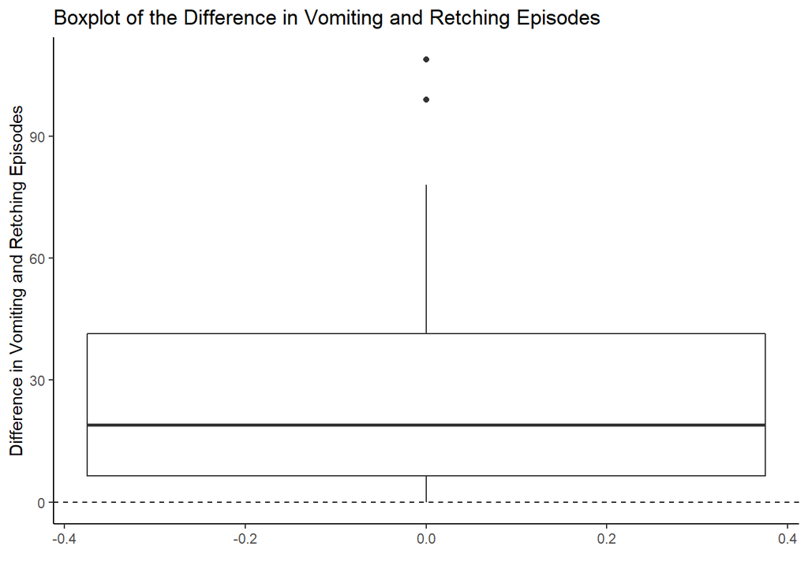

```r
###############################################################################


#creating a new variable looking at the difference of vomiting and retching episodes by treatment type
cancer <- cancer %>%
  mutate(diff = Placebo - Marijuana)


#boxplot of the difference in vomiting and retching episodes
cancer %>%
  ggplot() +
  geom_boxplot(aes(y = diff)) +
  labs(title = "Boxplot of the Difference in Vomiting and Retching Episodes",
       y = "Difference in Vomiting and Retching Episodes",
       x = "") +
  geom_hline(yintercept = 0, linetype = 2) +
  theme_classic()
```

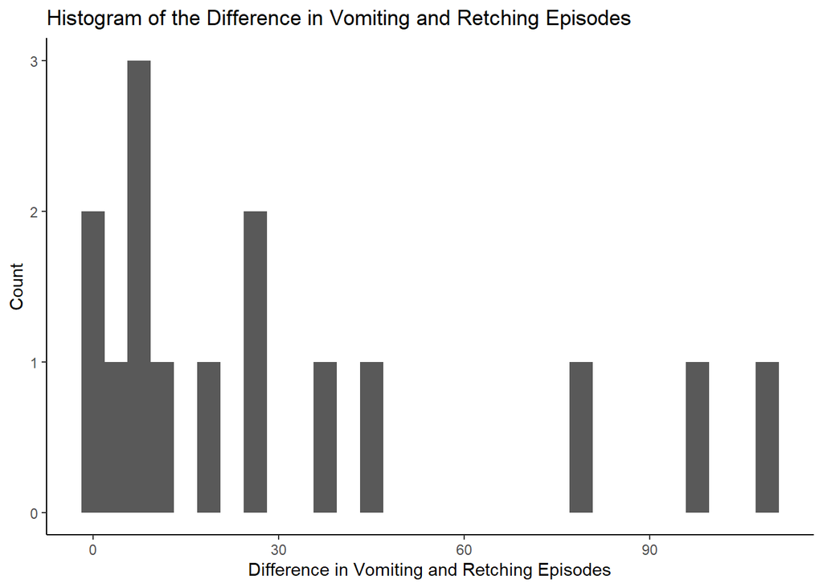

```r
#histogram of the difference in vomiting and retching episodes
cancer %>%
  ggplot() +
  geom_histogram(aes(x = diff)) +
  labs(title = "Histogram of the Difference in Vomiting and Retching Episodes",
       x = "Difference in Vomiting and Retching Episodes",
       y = "Count") +
  theme_classic()
```

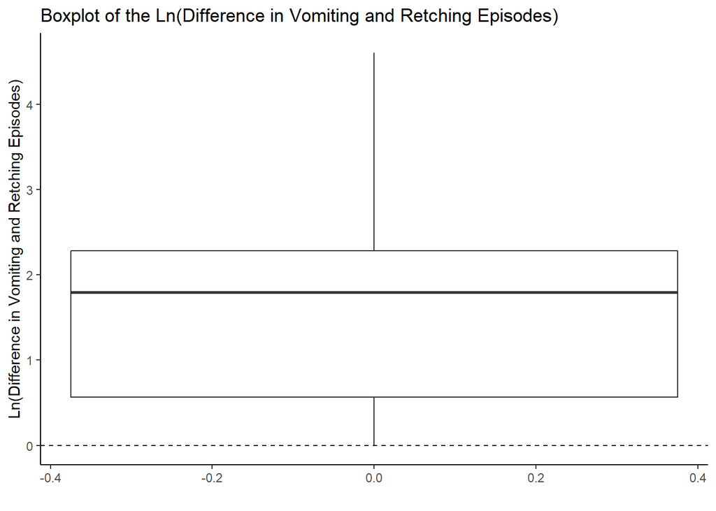

```r
###############################################################################


#logging the variables of interest and then looking at the difference
cancer <- cancer %>%
  mutate(log_marijuana = log(Marijuana + 1),
         log_placebo = log(Placebo + 1),
         diff_of_logs = log_placebo - log_marijuana)


#boxplot of the difference in vomiting and retching episodes
cancer %>%
  ggplot() +
  geom_boxplot(aes(y = diff_of_logs)) +
  labs(title = "Boxplot of the Ln(Difference in Vomiting and Retching Episodes) ",
       y = "Ln(Difference in Vomiting and Retching Episodes)",
       x = "") +
  geom_hline(yintercept = 0, linetype = 2) +
  theme_classic()
```

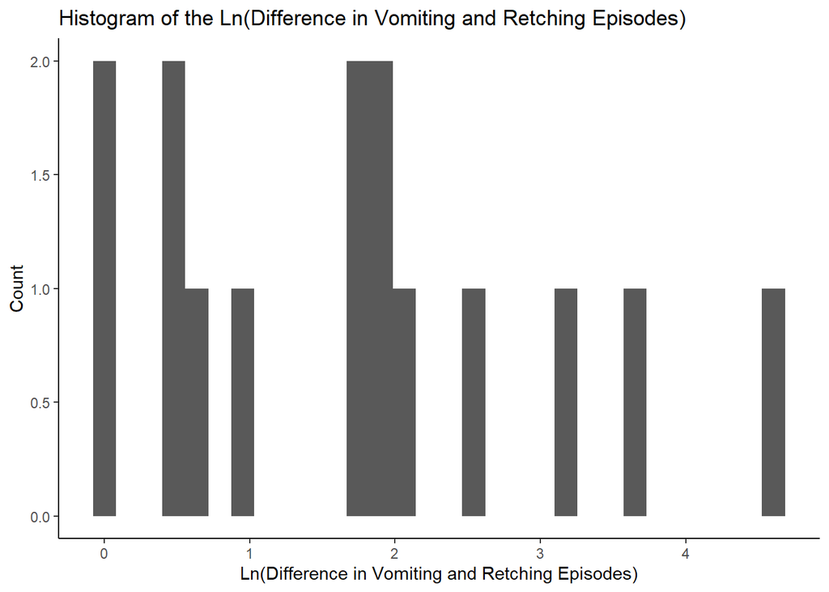

```r
#histogram of the difference in vomiting and retching episodes
cancer %>%
  ggplot() +
  geom_histogram(aes(x = diff_of_logs)) +
  labs(title = "Histogram of the Ln(Difference in Vomiting and Retching Episodes)",
       x = "Ln(Difference in Vomiting and Retching Episodes)",
       y = "Count") +
  theme_classic()
```

```r
#running the Wilcoxon Signed-Rank Test
wilcox.test(log_episodes ~ Treatment, data = cancer_long, paired = TRUE)
```

```
##
##  Wilcoxon signed rank test with continuity correction
##
## data:  log_episodes by Treatment
## V = 0, p-value = 0.001662
## alternative hypothesis: true location shift is not equal to 0
```

```r
#running the Wilcoxon Signed-Rank Test from the {asht} package
t2 <- wsrTest(cancer$log_placebo, cancer$log_marijuana)
t2
```

```
##
##  Exact Wilcoxon Signed-Rank Test (with Pratt modification if zeros)
##
## data:  cancer$log_placebo minus cancer$log_marijuana
## p-value = 0.0002441
## alternative hypothesis: true median is not equal to 0
## 95 percent confidence interval:
##  0.928 2.505
## sample estimates:
## median (Hodges-Lehmann estimator)
##                          1.762917
```

```r
(exp(t2$est[1])) - 1
```

```
## median (Hodges-Lehmann estimator)
##                          4.829415
```

```r
(exp(t2$conf.int)) - 1
```

```
## [1]  1.529445 11.243559
## attr(,"conf.level")
## [1] 0.95
```

**Basic Sleuth3::4.32** Your answer was superb: both code and summary based on the code **Score: 5/5**

# Supplemental Problems

## 4.30 (Sleuth 2nd Edition)

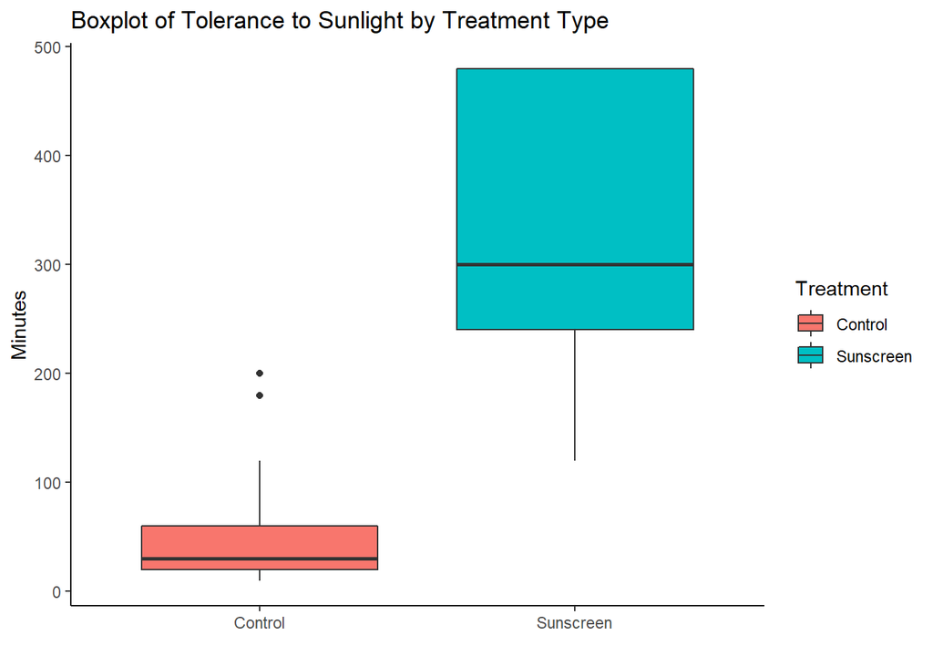

```r
#pulling the data from the 'Sleuth 2' package
spf <- Sleuth2::ex0430

#transforming the data so it's in long form
spf_long <- spf %>%
  pivot_longer(cols = c(Control, Sunscreen),
               names_to = "Treatment",
               values_to = "Minutes")

#boxplot of vomiting and retching episodes by treatment type
spf_long %>%
  ggplot() +
  geom_boxplot(aes(x = Treatment, y = Minutes, fill = Treatment)) +
  labs(title = "Boxplot of Tolerance to Sunlight by Treatment Type",
       x = "") +
  theme_classic()
```

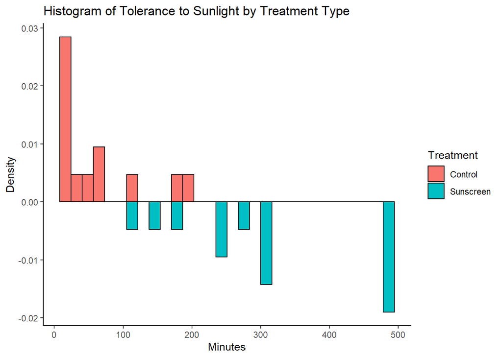

```r
#histogram of vomiting and retching episodes by treatment type
spf_long %>%
  ggplot() +
  geom_histogram(data = spf_long %>%
                   filter(Treatment == "Control"),
                 aes(x = Minutes, y = ..density.., fill = Treatment), color = "black") +
  geom_histogram(data = spf_long %>%
                   filter(Treatment == "Sunscreen"),
                 aes(x = Minutes, y = -..density.., fill = Treatment), color = "black") +
  labs(title = "Histogram of Tolerance to Sunlight by Treatment Type",
       y = "Density") +
  theme_classic()
```

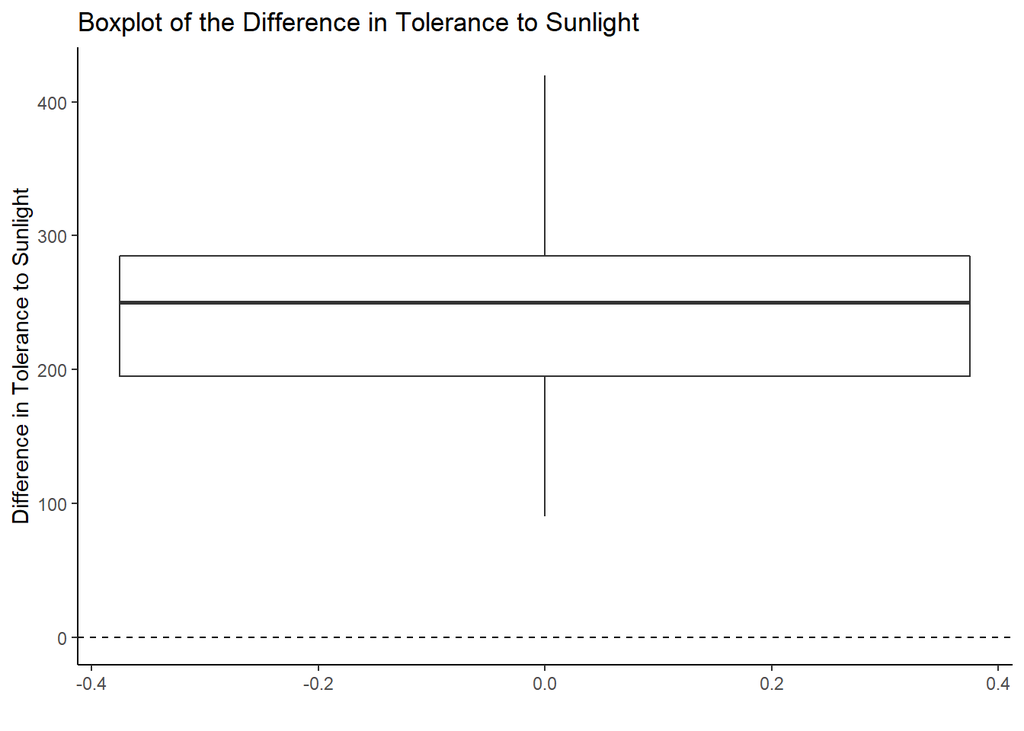

```r
###############################################################################


#creating a new variable looking at the difference of vomiting and retching episodes by treatment type
spf <- spf %>%
  mutate(diff = Sunscreen - Control)


#boxplot of the difference in vomiting and retching episodes
spf %>%
  ggplot() +
  geom_boxplot(aes(y = diff)) +
  labs(title = "Boxplot of the Difference in Tolerance to Sunlight",
       y = "Difference in Tolerance to Sunlight",
       x = "") +
  geom_hline(yintercept = 0, linetype = 2) +
  theme_classic()
```

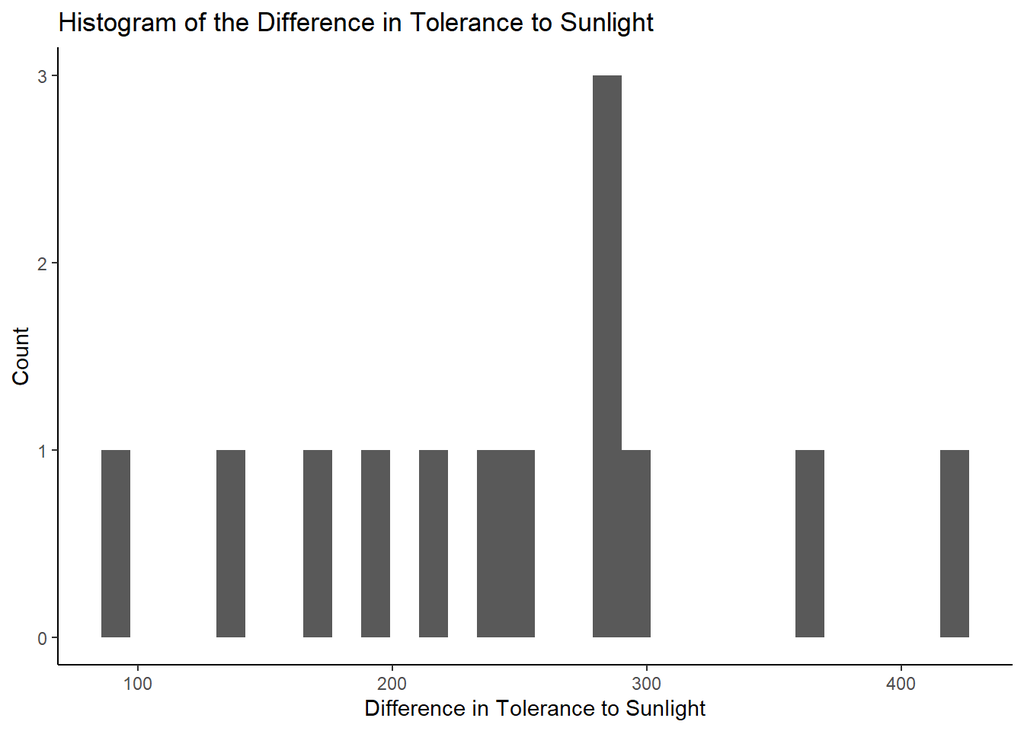

```r
#histogram of the difference in vomiting and retching episodes
spf %>%
  ggplot() +
  geom_histogram(aes(x = diff)) +
  labs(title = "Histogram of the Difference in Tolerance to Sunlight",
       x = "Difference in Tolerance to Sunlight",
       y = "Count") +
  theme_classic()
```

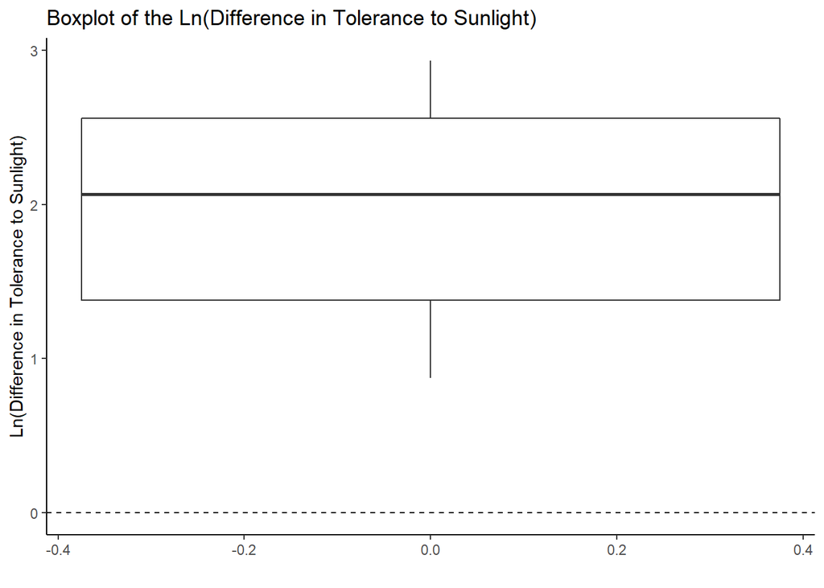

```r
###############################################################################


#logging the variables of interest and then looking at the difference
spf <- spf %>%
  mutate(log_control = log(Control + 1),
         log_sunscreen = log(Sunscreen + 1),
         diff_of_logs = log_sunscreen - log_control)


#boxplot of the difference in vomiting and retching episodes
spf %>%
  ggplot() +
  geom_boxplot(aes(y = diff_of_logs)) +
  labs(title = "Boxplot of the Ln(Difference in Tolerance to Sunlight) ",
       y = "Ln(Difference in Tolerance to Sunlight)",
       x = "") +
  geom_hline(yintercept = 0, linetype = 2) +
  theme_classic()
```

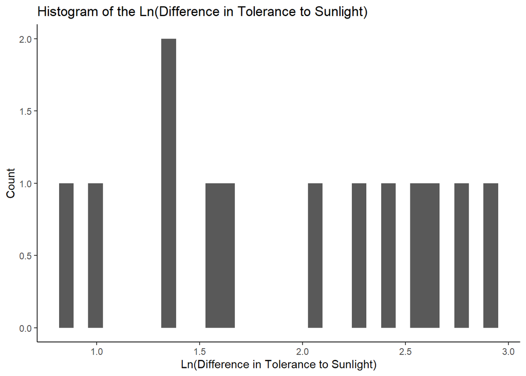

```r
#histogram of the difference in vomiting and retching episodes
spf %>%
  ggplot() +
  geom_histogram(aes(x = diff_of_logs)) +
  labs(title = "Histogram of the Ln(Difference in Tolerance to Sunlight)",
       x = "Ln(Difference in Tolerance to Sunlight)",
       y = "Count") +
  theme_classic()
```

```r
###############################################################################


#running the Wilcoxon Signed-Rank Test from the {asht} package
t3 <- wsrTest(spf$log_sunscreen, spf$log_control)
t3
```

```
##
##  Exact Wilcoxon Signed-Rank Test (with Pratt modification if zeros)
##
## data:  spf$log_sunscreen minus spf$log_control
## p-value = 0.0002441
## alternative hypothesis: true median is not equal to 0
## 95 percent confidence interval:
##  1.5089 2.4536
## sample estimates:
## median (Hodges-Lehmann estimator)
##                          1.959703
```

```r
(exp(t3$est[1]))
```

```
## median (Hodges-Lehmann estimator)
##                          7.097222
```

```r
(exp(t3$conf.int))
```

```
## [1]  4.521754 11.630140
## attr(,"conf.level")
## [1] 0.95
```

The histograms show that the control and sunscreen data for the sunlight protection factor are not normally distributed. However, because the data are paired, two observations (control/sunscreen) from one study unit (patient) the difference in tolerance to sunlight needs to be investigated. The difference in tolerance to sunlight is not normally distributed but it is relatively symmetric, however, because the analysis of the sunlight protection factor is interested in a ratio, a log-transformation was performed. The histograms of the log-transformed data show that they are relatively symmetric, so the analysis was conducted with the log-transformed data. There is overwhelming evidence that the difference between the control and sunscreen treatments in the patients is nonzero (two-sided p-value < 0.001 from a paired Wilcoxon Signed-Rank Test). The sunscreen treatment has a median tolerance to sunlight 7.10 times greater that of the median for control treatment (95% confidence interval: 4.52 to 11.63).

**Supplemental Sleuth2::0430:** Excellent answer! Yours was the best analysis that I received on this and the other questions. I would have had you present, but others who hadn’t presented before are presenting. You’ve presented twice already **Score: 2.5/2.5**

## 4.31 (Sleuth 2nd Edition)

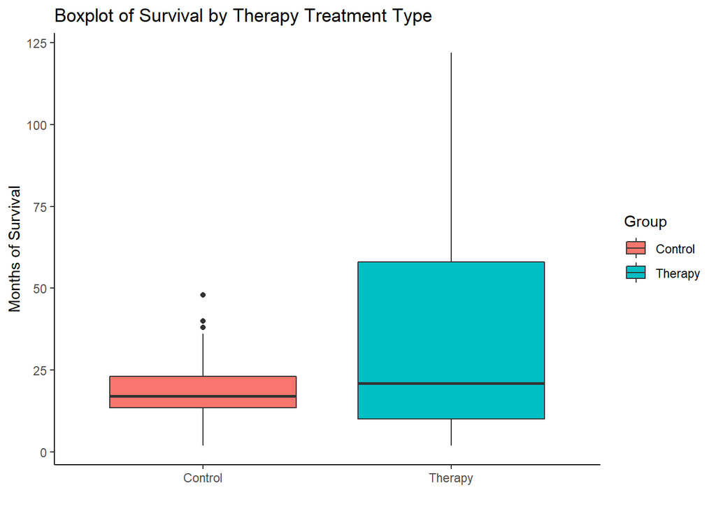

```r
#pulling the data from the 'Sleuth 2' package
cancer2 <- Sleuth2::ex0431


#boxplot of survival by therapy treatment type
cancer2 %>%
  ggplot() +
  geom_boxplot(aes(x = Group, y = Survival, fill = Group)) +
  labs(title = "Boxplot of Survival by Therapy Treatment Type",
       x = "", y = "Months of Survival") +
  theme_classic()
```

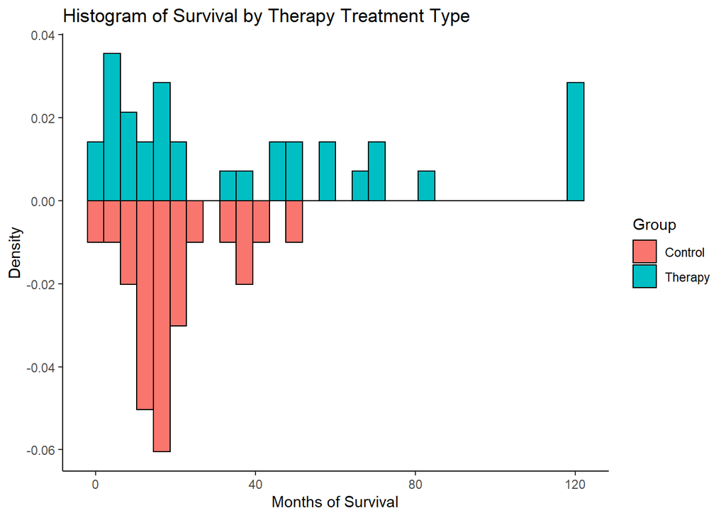

```r
#histogram of survival by therapy treatment type
cancer2 %>%
  ggplot() +
  geom_histogram(data = cancer2 %>%
                   filter(Group == "Therapy"),
                 aes(x = Survival, y = ..density.., fill = Group), color = "black") +
  geom_histogram(data = cancer2 %>%
                   filter(Group == "Control"),
                 aes(x = Survival, y = -..density.., fill = Group), color = "black") +
  labs(title = "Histogram of Survival by Therapy Treatment Type",
       y = "Density", x = "Months of Survival") +
  theme_classic()
```

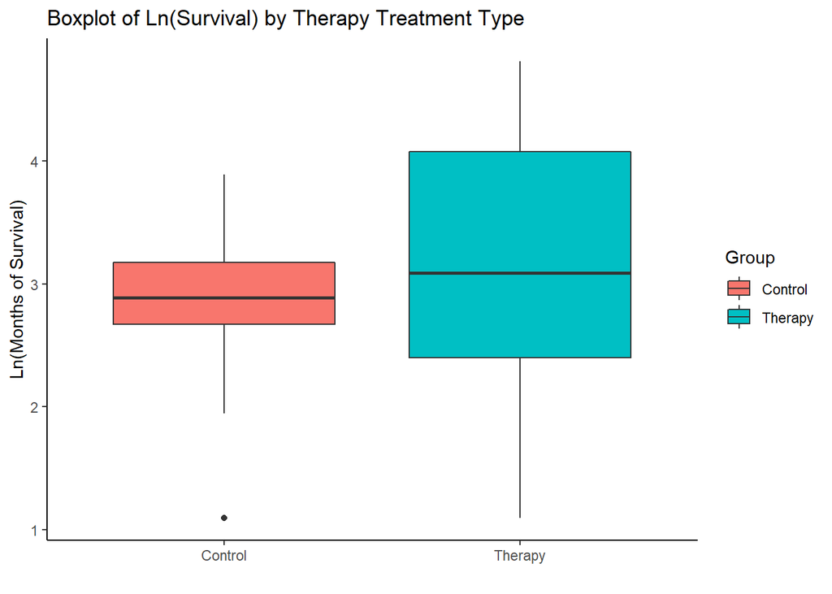

```r
###############################################################################

#log transforming the data
cancer2 <- cancer2 %>%
  mutate(log_survival = log(Survival + 1))

#boxplot of ln(survival) by therapy treatment type
cancer2 %>%
  ggplot() +
  geom_boxplot(aes(x = Group, y = log_survival, fill = Group)) +
  labs(title = "Boxplot of Ln(Survival) by Therapy Treatment Type",
       x = "", y = "Ln(Months of Survival)") +
  theme_classic()
```

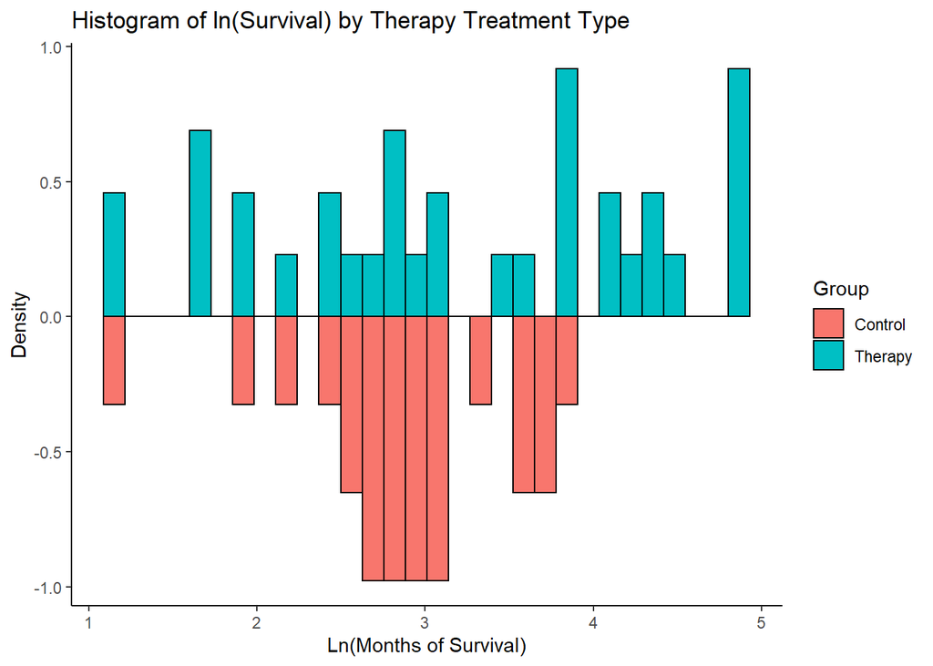

```r
#histogram of ln(survival) by therapy treatment type
cancer2 %>%
  ggplot() +
  geom_histogram(data = cancer2 %>%
                   filter(Group == "Therapy"),
                 aes(x = log_survival, y = ..density.., fill = Group), color = "black") +
  geom_histogram(data = cancer2 %>%
                   filter(Group == "Control"),
                 aes(x = log_survival, y = -..density.., fill = Group), color = "black") +
  labs(title = "Histogram of ln(Survival) by Therapy Treatment Type",
       y = "Density", x = "Ln(Months of Survival)") +
  theme_classic()
```

```r
###############################################################################



#running the Wilcoxon Rank-Sum Test
wilcox.test(log_survival ~ Group, data = cancer2, correct = TRUE,
            alternative = "two.sided", conf.int=TRUE)
```

```
##
##  Wilcoxon rank sum test with continuity correction
##
## data:  log_survival by Group
## W = 337, p-value = 0.265
## alternative hypothesis: true location shift is not equal to 0
## 95 percent confidence interval:
##  -0.9314826  0.2363959
## sample estimates:
## difference in location
##              -0.302265
```

```r
#changing the dataframe structure so it can run in the asht package
cancer2 <- cancer2 %>%
  group_by(Group) %>%
  mutate(grouped_id = row_number())
cancer2_wide <- cancer2 %>%
  select(-c(Survival, Censor)) %>%
  spread(Group, log_survival) %>%
  select(-grouped_id)


#running the Wilcoxon Rank-Sum Test from asht package
t4 <- wmwTest(cancer2_wide$Control, cancer2_wide$Therapy, correct = TRUE)
t4
```

```
##
##  Wilcoxon-Mann-Whitney test with continuity correction (confidence
##  interval requires proportional odds assumption, but test does not)
##
## data:  cancer2_wide$Control and cancer2_wide$Therapy
## Mann-Whitney estimate = 0.58701, tie factor = 0.99695, p-value = 0.265
## alternative hypothesis: two distributions are not equal
## 95 percent confidence interval:
##  0.4360012 0.7209866
## sample estimates:
## Mann-Whitney estimate
##             0.5870098
```

```r
(exp(t4$est[1])) - 1
```

```
## Mann-Whitney estimate
##             0.7986022
```

```r
(exp(t4$conf.int)) - 1
```

```
## [1] 0.5465106 1.0564611
## attr(,"conf.level")
## [1] 0.95
```

**Supplemental Sleuth2::0431:** Your answer is very good. In fact, the Sleuth authors in their answer key argue for the use of the Wilcoxon rank sum test because of the censored data at Month 122 (i.e., the patients didn’t die). Unfortunately with rank sum test has an equal spread assumption, and since the log-transform is rank-perserving (you get the same result whether you log transform or not), the rank sum (or the equivalent Mann-Whitney U test should not be used.). I think the only two tests that are appropriate are the Welch’s test or the t test after a log transform. The truncated data at 122 months pose a problem, but less of a problem than unequal spreads. Craig Schaffer will be presenting his Welch t test solution (19 month difference with 95% CI of 5 & 36, p value 0.008** Score: 2.5/2.5**